# A3 - Data Visualization (Incarceration)

Maoyi Liao

2022-05-22

## Introduction.

In this incarceration data, I choose 8 variables to analyze. They are “year”, and the jail population from total and different races, such as “total jail population”, “Jail Population Count, Asian American / Pacific Islander”, “Jail Population Count, Black”, “Jail Population Count, Latinx”, “Jail Population Count, Native American”, “Jail Population Count, White”, and “Unknown or Other Racial Category”.

## There are 5 relevant values of interest.

- The mean of each value in most recent year(2018):

```
## [1] 248.944975   2.389794  83.602482  38.293354   3.483077 116.872256   1.291223
```

- The difference between the max and min mean number in different races:

```
## [1] 247.6538
```

- the highest number of jail population in each race:

```
## [1] 17208.0   286.4  5024.0  8728.0   379.0  4577.0   608.0
```

- the lowest number of jail population in each race:

```
## [1] 0 0 0 0 0 0 0
```

- the number of people are incarcerated in different racial groups in different years:

```
## # A tibble: 49 × 8
##     year total_jail_pop aapi_jail_pop black_jail_pop latinx_jail_pop
##    <int>          <dbl>         <dbl>          <dbl>           <dbl>
##  1  1970          1456.             0              0               0
##  2  1971          1427.             0              0               0
##  3  1972          1489.             0              0               0
##  4  1973          1551.             0              0               0
##  5  1974          1613.             0              0               0
##  6  1975          1675.             0              0               0
##  7  1976          1736.             0              0               0
##  8  1977          1798.             0              0               0
##  9  1978          1993.             0              0               0
## 10  1979          2589.             0              0               0
## # … with 39 more rows, and 3 more variables: native_jail_pop <dbl>,
## #   white_jail_pop <dbl>, other_race_jail_pop <dbl>
```

From this table, we could see the change of jail population in different racial groups within the years.

## Trends over time chart

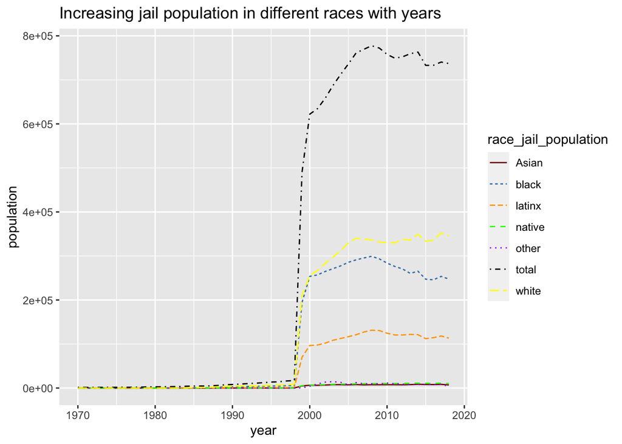

The chart I made shows the jail population in different races increased with time. I created this graph to demonstrate how much and how quickly the jail population grows in different races in comparison. This will be more visually appealing. According to the graph, the total jail population increased significantly between 1995 and 2000, with the white population increasing the most, followed by the black and latinx populations.

## Variable comparison chart

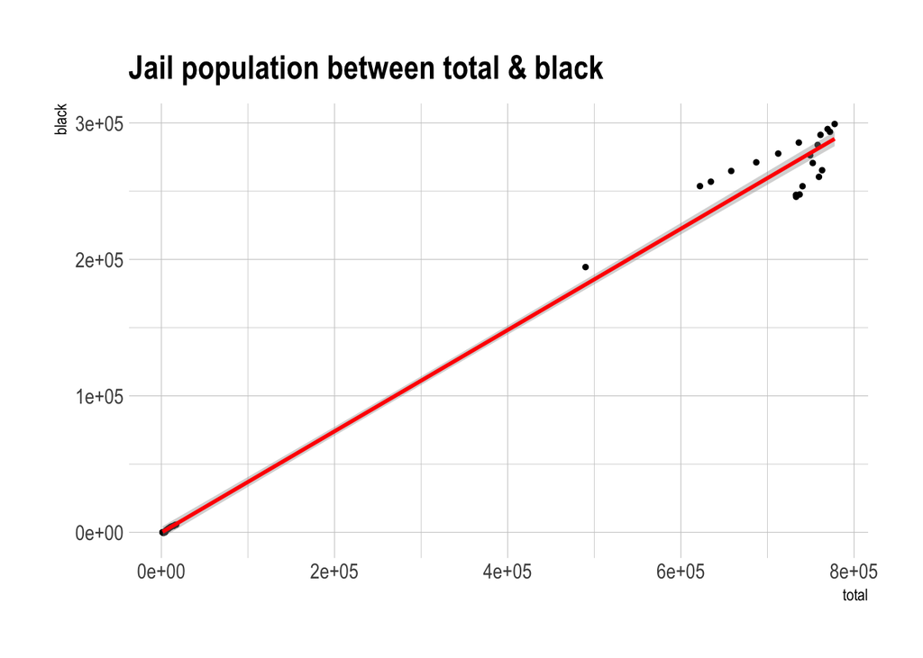

This graph depicts the relationship between the black and total prison populations. I included this chart to see if the increasing jail population in black is related to the overall increasing population. According to the graph, as the total jail population increased, so did the black jail population. As a result, they have a positive relationship.

## Map

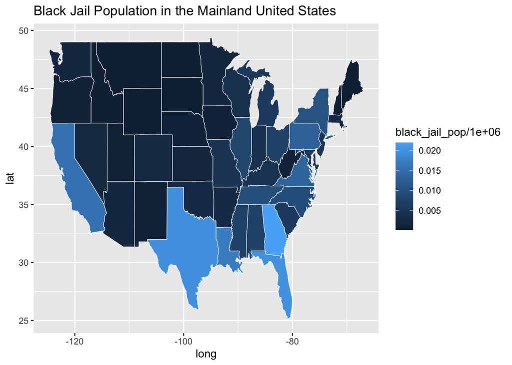

[figure not shown]